# **O problema da (quase) separação na análise de dados binários**

$$\mathbf{Prof.\ Cesar\ Augusto\ Taconeli}$$

$$\mathbf{Modelos\ Lineares\ Generalizados\ (CE225)}$$

$$\mathbf{Outubro/2017}$$

## Definição

O problema da separação, na regressão para dados binários, se caracteriza pela existência deum hiperplano no espaço das covariáveis que separe perfeitamente as observações com $y=0$ das observações com $y=1$.

## A toy example

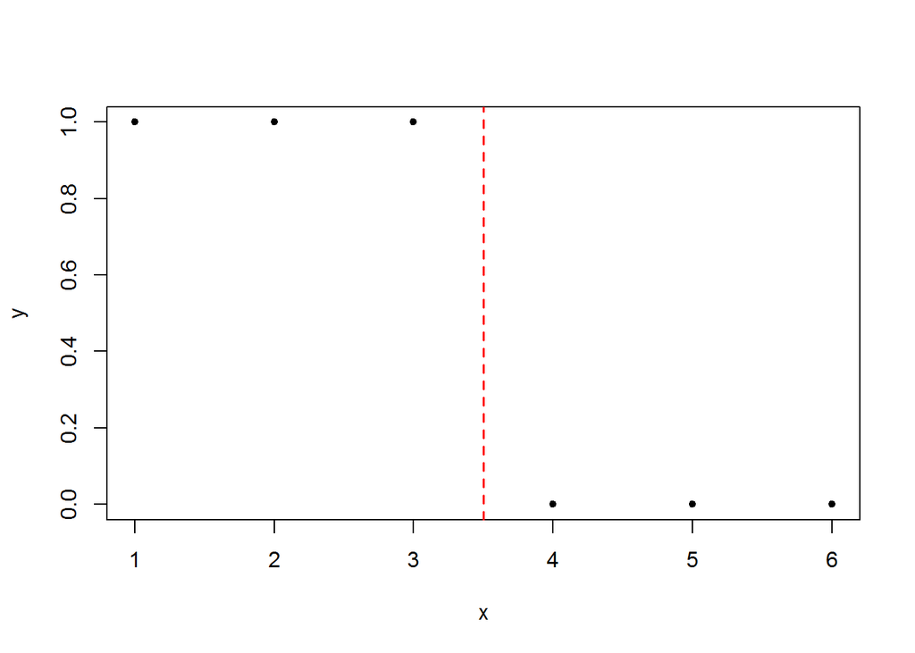

```r
x <- 1:6
y <- c(1, 1, 1, 0, 0, 0)
plot(x, y, pch = 20)
abline(v = 3.5, col = 'red', lty = 2, lwd = 1.5)
```

Observe que a reta $x=3.5$ separa completamente observações com cada valor da resposta. Vamos ajustar um MLG com distribuição binomial.

```r
ajuste <- glm(y ~ x, family = 'binomial')
summary(ajuste)
```

```
Call:
glm(formula = y ~ x, family = "binomial")

Deviance Residuals:
         1           2           3           4           5           6
 2.110e-08   2.110e-08   1.052e-05  -1.052e-05  -2.110e-08  -2.110e-08

Coefficients:
             Estimate Std. Error z value Pr(>|z|)
(Intercept)    165.32  407521.43       0        1
x              -47.23  115264.41       0        1

(Dispersion parameter for binomial family taken to be 1)

    Null deviance: 8.3178e+00  on 5  degrees of freedom
Residual deviance: 2.2152e-10  on 4  degrees of freedom
AIC: 4

Number of Fisher Scoring iterations: 25
```

```r
confint.default(ajuste)
```

```
                2.5 %   97.5 %
(Intercept) -798562.0 798892.6
x           -225961.3 225866.9
```

```r
predict(ajuste, type = 'response')
```

```
           1            2            3            4            5
1.000000e+00 1.000000e+00 1.000000e+00 5.537833e-11 2.220446e-16
           6
2.220446e-16
```

Observe que as estimativas pontuais e os erros padrões (principalmente) são excessivamente grandes. Como resultado, o resultado do teste de Wald é contraditório e os intervalos de confiança baseados nesse teste são absurdamente largos. Isso é resultado de estimativas para $\pi$ iguais a zero e iguais a 1.

Nesse caso, se fixarmos $\hat{\beta}_0 = -3.5\hat{\beta}_1$ (tal que = 0.5 em $x=3.5$) e fizermos $\hat{\beta} \rightarrow -\infty$, temos uma sequência de ajustes

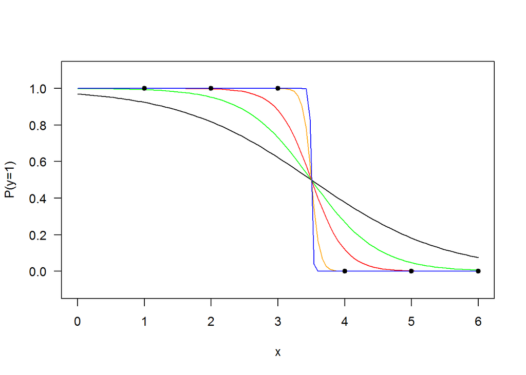

```r
### Sequência de ajustes com maior log-verossimilhança.
inv_logit <- function(beta0, beta1, x) exp(beta0 + beta1 * x)/(exp(beta0 + beta1 * x) + 1)
curve(inv_logit(3.5, -1, x), 0, 6, las = 1, ylim = c(-0.1, 1.1), ylab = 'P(y=1)')
curve(inv_logit(7, -2, x), 0, 6, add = TRUE, col = 'green')
curve(inv_logit(14, -4, x), 0, 6, add = TRUE, col = 'red')
curve(inv_logit(56, -16, x), 0, 6, add = TRUE, col = 'orange')
curve(inv_logit(280, -80, x), 0, 6, add = TRUE, col = 'blue')
points(x, y, cex = 1.2, pch = 20)
```

Na prática, o software não identifica que a estimativa de máxima verossimilhança não é finita. Após certo número de iterações, a log-verossimilhança aumenta com menor intensidade e o critério de convergência é satisfeito, e o software retorna as estimativas.

Os erros padrões inflacionados são resultantes da forma da função de verossimilhança, que é plana, e não côncava. Isso gera pequena informação e grande variância, consequentemente.

Embora os resultados baseados na normalidade assintótica dos estimadores estejam comprometidos, o teste da sazão de verossimilhanças ainda é válido.

```r
anova(ajuste, test = 'Chisq')
```

```
Analysis of Deviance Table

Model: binomial, link: logit

Response: y

Terms added sequentially (first to last)

     Df Deviance Resid. Df Resid. Dev Pr(>Chi)
NULL                     5     8.3178
x     1   8.3178         4     0.0000 0.003926 **
---
Signif. codes:  0 '***' 0.001 '**' 0.01 '*' 0.05 '.' 0.1 ' ' 1
```

Pelo TRV fica claro que $P(y=1)$ diminui à medida que $x$ aumenta, diferentemente do verificado para o teste de Wald, e bem mais compatível com os dados. Vamos ver como ficam os ICs baseados nos perfis de verossimilhança:

```r
confint(ajuste)
```

```
               2.5 %   97.5 %
(Intercept) 166809.4 240668.7
x                 NA  11009.6
```

Observe que, dado o comportamento da função de verossimilhança, o intervalo de confiança baseado no perfil de verossimilhança para $\hat{\beta}_1$ não retorna um limite inferior.

O fenômeno da quase-separação, por sua vez, se caracteriza quando há um hiperplano separando as observações com $y=0$ das observações com $y=1$, mas há resultados sobre o hiperplano. Este caso é mais comum para o caso de covariáveis qualitativas (fatores) do que qualitativas.

## Exemplo - Fatores de risco para o estágio de câncer no endométrio

Variáveis:

```
_ HG - estágio (0 para moderado, 1 para avançado);
_ NV - neovasculação (0 para ausente, 1 para presente);
_ PI - índice de pulsatilidade da artéria uterina (numérico);
_ EH - tamanho do endométrio (numérico).
```

```r
setwd("c:/Users/Samsung/Dropbox/Backup Parana/Parana/Disciplinas/Modelos Lineares Generalizados/Oferta 2017")
dados <- read.table('Endometrial.txt', header = T)
dados$NV <- factor(dados$NV)
table(dados$HG, dados$NV)
```

```
     0  1
  0 49  0
  1 17 13
```

```r
ajuste_end <- glm(HG ~ NV + PI + EH, family = binomial, data = dados)
summary(ajuste_end)
```

```
Call:
glm(formula = HG ~ NV + PI + EH, family = binomial, data = dados)

Deviance Residuals:
     Min        1Q    Median        3Q       Max
-1.50137  -0.64108  -0.29432   0.00016   2.72777

Coefficients:
              Estimate Std. Error z value Pr(>|z|)
(Intercept)    4.30452    1.63730   2.629 0.008563 **
NV1           18.18556 1715.75089   0.011 0.991543
PI            -0.04218    0.04433  -0.952 0.341333
EH            -2.90261    0.84555  -3.433 0.000597 ***
---
Signif. codes:  0 '***' 0.001 '**' 0.01 '*' 0.05 '.' 0.1 ' ' 1

(Dispersion parameter for binomial family taken to be 1)

    Null deviance: 104.903  on 78  degrees of freedom
Residual deviance:  55.393  on 75  degrees of freedom
AIC: 63.393

Number of Fisher Scoring iterations: 17
```

Observe que todos os 13 pacientes com neovasculação apresentam $y=1$, ou seja, estágio avançado para o câncer do endométrio. Isso gera quase-separação, o que fica evidente pelas estimativas associadas à presença de neovasculação. Novamente as inferências baseadas no método de Wald. O teste da razão de verossimilhanças, no entanto, continua válido.

```r
Anova(ajuste_end)
```

```
Analysis of Deviance Table (Type II tests)

Response: HG
   LR Chisq Df Pr(>Chisq)
NV   9.3576  1   0.002221 **
PI   0.9851  1   0.320934
EH  19.7606  1  8.777e-06 ***
---
Signif. codes:  0 '***' 0.001 '**' 0.01 '*' 0.05 '.' 0.1 ' ' 1
```

Observe que as estimativas dos demais parâmetros não são afetadas pelo problema da quase-separação.

Como soluções para o problema de (quase) separação temos:

```
_ Análise Bayesiana;
_ Ajuste baseado em verossimilhança penalizada (métodos de regularização).
```